# Module 03: Measurement — Exploratory and Confirmatory Factor Analysis

## 4.6 Visualising the Factor Structure

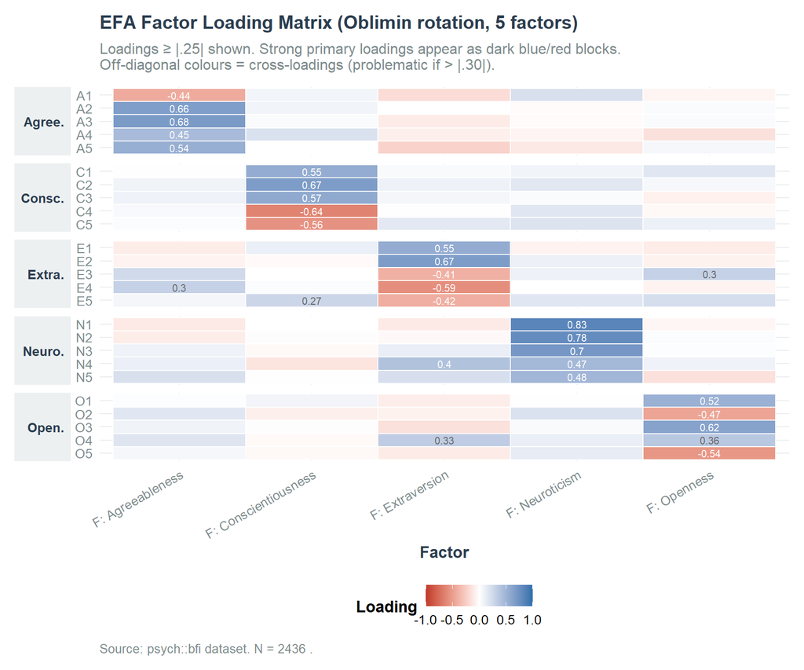

```r
L_df <- as.data.frame(L) |>
  rownames_to_column("Item") |>
  mutate(
    Trait = str_extract(Item, "^[A-Z]"),
    Trait = dplyr::recode(Trait, A="Agree.", C="Consc.", E="Extra.", N="Neuro.", O="Open.")
  ) |>
  pivot_longer(starts_with("MR"), names_to="Factor", values_to="Loading")

# Map factor names based on which items load highest
factor_labels <- L_df |>
  group_by(Factor) |>
  slice_max(abs(Loading), n=3) |>
  summarise(top_trait = names(which.max(table(str_extract(Item,"^[A-Z]")))),
            .groups="drop") |>
  mutate(Label = dplyr::recode(top_trait,
    A="F: Agreeableness", C="F: Conscientiousness",
    E="F: Extraversion",  N="F: Neuroticism", O="F: Openness"))

L_df <- L_df |>
  left_join(factor_labels, by="Factor")

ggplot(L_df, aes(x=Label, y=fct_rev(Item), fill=Loading)) +
  geom_tile(colour="white", linewidth=0.4) +
  geom_text(aes(label=ifelse(abs(Loading) >= 0.25, round(Loading,2), ""),
                colour=abs(Loading) > 0.4),
            size=2.9) +
  scale_fill_gradient2(low="#C0392B", mid="white", high="#2C6FAC",
                       midpoint=0, limits=c(-1,1), name="Loading") +
  scale_colour_manual(values=c("FALSE"="grey40","TRUE"="white"), guide="none") +
  facet_grid(Trait~., scales="free_y", space="free_y", switch="y") +
  labs(
    title    = "EFA Factor Loading Matrix (Oblimin rotation, 5 factors)",
    subtitle = paste("Loadings ≥ |.25| shown. Strong primary loadings appear as dark blue/red blocks.",
                     "\nOff-diagonal colours = cross-loadings (problematic if > |.30|)."),
    x="Factor", y=NULL,
    caption  = paste("Source: psych::bfi dataset. N =", nrow(bfi_complete), ".")
  ) +
  theme(axis.text.x=element_text(angle=30, hjust=1),
        strip.text.y.left=element_text(angle=0, hjust=1, face="bold"),
        strip.placement="outside")
```

**Reading the heatmap:** Each row is an item; each column is a factor. Dark blue in a cell = strong positive loading. Dark red = strong negative loading. White = near-zero loading. A clean five-factor solution shows five “hot spots” on the diagonal — each block of items (A1–A5, C1–C5, etc.) loads strongly on one factor and weakly on all others. Cross-loadings (substantial colours off the diagonal) indicate items that do not fit cleanly into the proposed structure.